DS 6030 | Fall 2024 | University of Virginia

# Homework #7: Stacking and Boosting

Author

**Ashley Miller**

Published

October 29, 2024

# Stacking for Kaggle

You are to make at least one official entry in the [House Prices: Advanced Regression Techniques](https://www.kaggle.com/c/house-prices-advanced-regression-techniques/overview) Kaggle contest **using stacking or model averaging**; at least one component model must be a boosting model.

- You will need to register in Kaggle (its free)
- Read the details of the contest. Understand the data and evaluation function.
- Make at least one submission that uses **stacking or model averaging**.
- If you get a score on the public leaderboard of $\text{RMSE}<0.50$ (note RMSE is calculated on the log scale), you receive full credit, otherwise, you’ll lose 10 points.
  - I’ll allow [teaming](https://www.kaggle.com/c/house-prices-advanced-regression-techniques/team). Each team member can produce one component model and then use stacking or model averaging to combine predictions.
  - You don’t need to team, but must still combine multiple models. At least one of the component models should be boosting.
- Each person submit the following in Canvas:
  - Code (if teaming, your code and the shared stacking code)
  - kaggle name (or team name) so we can ensure you had a valid submission.
  - your score and current ranking on the kaggle leaderboard
- Top 5 scores get 2 bonus points
  - Teams will split their bonus points among team members

Note: Check out the [Kaggle notebooks](https://www.kaggle.com/docs/notebooks) which let you make submissions directly from the notebook. Its very similar to using Rivanna’s OnDemand in that you can make a RMarkdown/Jupyter notebook or R/Python scrips that run on the cloud. Free CPU (4 cores, 30GB RAM) - amazing! Let your laptops cool off after all their hard work this semester.

```r
train = read.csv("train.csv")
test = read.csv("test.csv")
levels(train$Alley)
```

```r
mode <- function(x) {
  ux <- unique(na.omit(x))
  ux[which.max(tabulate(match(x, ux)))]
}
```

```r
train$LotFrontage[is.na(train$LotFrontage)] = 0
train$Alley[is.na(train$Alley)] = "None"
train$MasVnrType[is.na(train$MasVnrType)] = "None"
train$MasVnrArea[is.na(train$MasVnrArea)] = 0
train$BsmtQual[is.na(train$BsmtQual)] = "TA"
train$BsmtCond[is.na(train$BsmtCond)] = "TA"
train$BsmtExposure[is.na(train$BsmtExposure)] = "No"
train$BsmtFinType1[is.na(train$BsmtFinType1)] = "None"
train$BsmtFinType2[is.na(train$BsmtFinType2)] = "None"
train$Electrical[is.na(train$Electrical)] = "SBrkr"
train$FireplaceQu[is.na(train$FireplaceQu)] = "None"
train$GarageType[is.na(train$GarageType)] = "None"
train$GarageYrBlt[is.na(train$GarageYrBlt)] = mode(train$GarageYrBlt)
train$GarageFinish[is.na(train$GarageFinish)] = "None"
train$GarageQual[is.na(train$GarageQual)] = mode(train$GarageQual)
train$GarageCond[is.na(train$GarageCond)] = mode(train$GarageCond)
train$PoolQC[is.na(train$PoolQC)] = "None"
train$Fence[is.na(train$Fence)] = "None"
train$MiscFeature[is.na(train$MiscFeature)] = "None"
summary(is.na(train))
```

```
     Id          MSSubClass       MSZoning       LotFrontage
 Mode :logical   Mode :logical   Mode :logical   Mode :logical
 FALSE:1460      FALSE:1460      FALSE:1460      FALSE:1460
  LotArea          Street          Alley          LotShape
 Mode :logical   Mode :logical   Mode :logical   Mode :logical
 FALSE:1460      FALSE:1460      FALSE:1460      FALSE:1460
 LandContour     Utilities       LotConfig       LandSlope
 Mode :logical   Mode :logical   Mode :logical   Mode :logical
 FALSE:1460      FALSE:1460      FALSE:1460      FALSE:1460
 Neighborhood    Condition1      Condition2       BldgType
 Mode :logical   Mode :logical   Mode :logical   Mode :logical
 FALSE:1460      FALSE:1460      FALSE:1460      FALSE:1460
 HouseStyle      OverallQual     OverallCond     YearBuilt
 Mode :logical   Mode :logical   Mode :logical   Mode :logical
 FALSE:1460      FALSE:1460      FALSE:1460      FALSE:1460
 YearRemodAdd    RoofStyle        RoofMatl       Exterior1st
 Mode :logical   Mode :logical   Mode :logical   Mode :logical
 FALSE:1460      FALSE:1460      FALSE:1460      FALSE:1460
 Exterior2nd     MasVnrType      MasVnrArea      ExterQual
 Mode :logical   Mode :logical   Mode :logical   Mode :logical
 FALSE:1460      FALSE:1460      FALSE:1460      FALSE:1460
 ExterCond       Foundation       BsmtQual        BsmtCond
 Mode :logical   Mode :logical   Mode :logical   Mode :logical
 FALSE:1460      FALSE:1460      FALSE:1460      FALSE:1460
 BsmtExposure    BsmtFinType1    BsmtFinSF1      BsmtFinType2
 Mode :logical   Mode :logical   Mode :logical   Mode :logical
 FALSE:1460      FALSE:1460      FALSE:1460      FALSE:1460
 BsmtFinSF2      BsmtUnfSF       TotalBsmtSF      Heating
 Mode :logical   Mode :logical   Mode :logical   Mode :logical
 FALSE:1460      FALSE:1460      FALSE:1460      FALSE:1460
 HeatingQC       CentralAir      Electrical      X1stFlrSF
 Mode :logical   Mode :logical   Mode :logical   Mode :logical
 FALSE:1460      FALSE:1460      FALSE:1460      FALSE:1460
 X2ndFlrSF       LowQualFinSF    GrLivArea       BsmtFullBath
 Mode :logical   Mode :logical   Mode :logical   Mode :logical
 FALSE:1460      FALSE:1460      FALSE:1460      FALSE:1460
 BsmtHalfBath     FullBath        HalfBath       BedroomAbvGr
 Mode :logical   Mode :logical   Mode :logical   Mode :logical
 FALSE:1460      FALSE:1460      FALSE:1460      FALSE:1460
 KitchenAbvGr    KitchenQual     TotRmsAbvGrd    Functional
```

[output cut: 8 more lines]

```
 GarageCond      PavedDrive      WoodDeckSF      OpenPorchSF
 Mode :logical   Mode :logical   Mode :logical   Mode :logical
 FALSE:1460      FALSE:1460      FALSE:1460      FALSE:1460
 EnclosedPorch   X3SsnPorch      ScreenPorch      PoolArea
 Mode :logical   Mode :logical   Mode :logical   Mode :logical
 FALSE:1460      FALSE:1460      FALSE:1460      FALSE:1460
   PoolQC          Fence         MiscFeature      MiscVal
 Mode :logical   Mode :logical   Mode :logical   Mode :logical
 FALSE:1460      FALSE:1460      FALSE:1460      FALSE:1460
   MoSold          YrSold         SaleType       SaleCondition
 Mode :logical   Mode :logical   Mode :logical   Mode :logical
 FALSE:1460      FALSE:1460      FALSE:1460      FALSE:1460
 SalePrice
 Mode :logical
 FALSE:1460
```

```r
test$LotFrontage[is.na(test$LotFrontage)] = 0
test$Alley[is.na(test$Alley)] = "None"
test$MasVnrType[is.na(test$MasVnrType)] = "None"
test$MasVnrArea[is.na(test$MasVnrArea)] = 0
test$BsmtQual[is.na(test$BsmtQual)] = "TA"
test$BsmtCond[is.na(test$BsmtCond)] = "TA"
test$BsmtExposure[is.na(test$BsmtExposure)] = "No"
test$BsmtFinType1[is.na(test$BsmtFinType1)] = "None"
test$BsmtFinType2[is.na(test$BsmtFinType2)] = "None"
test$Electrical[is.na(test$Electrical)] = "SBrkr"
test$FireplaceQu[is.na(test$FireplaceQu)] = "None"
test$GarageType[is.na(test$GarageType)] = "None"
test$GarageYrBlt[is.na(test$GarageYrBlt)] = mode(test$GarageYrBlt)
test$GarageFinish[is.na(test$GarageFinish)] = "None"
test$GarageQual[is.na(test$GarageQual)] = mode(test$GarageQual)
test$GarageCond[is.na(test$GarageCond)] = mode(test$GarageCond)
test$PoolQC[is.na(test$PoolQC)] = "None"
test$Fence[is.na(test$Fence)] = "None"
test$MiscFeature[is.na(test$MiscFeature)] = "None"
test$MSZoning[is.na(test$MSZoning)] = mode(test$MSZoning)
test$Utilities[is.na(test$Utilities)] = mode(test$Utilities)
test$Exterior1st[is.na(test$Exterior1st)] = mode(test$Exterior1st)
test$Exterior2nd[is.na(test$Exterior2nd)] = mode(test$Exterior2nd)
test$BsmtFinSF1[is.na(test$BsmtFinSF1)] = 0
test$BsmtFinSF2[is.na(test$BsmtFinSF2)] = 0
test$BsmtUnfSF[is.na(test$BsmtUnfSF)] = 0
test$TotalBsmtSF[is.na(test$TotalBsmtSF)] = 0
test$BsmtFullBath[is.na(test$BsmtFullBath)] = 0
test$BsmtHalfBath[is.na(test$BsmtHalfBath)] = 0
test$KitchenQual[is.na(test$KitchenQual)] = mode(test$KitchenQual)
test$Functional[is.na(test$Functional)] = "Typ"
test$GarageCars[is.na(test$GarageCars)] = mode(test$GarageCars)
test$GarageArea[is.na(test$GarageArea)] = mean(na.omit(test$GarageArea))
test$SaleType[is.na(test$SaleType)] = mode(test$SaleType)
summary(is.na(test))
```

```
     Id          MSSubClass       MSZoning       LotFrontage
 Mode :logical   Mode :logical   Mode :logical   Mode :logical
 FALSE:1459      FALSE:1459      FALSE:1459      FALSE:1459
  LotArea          Street          Alley          LotShape
 Mode :logical   Mode :logical   Mode :logical   Mode :logical
 FALSE:1459      FALSE:1459      FALSE:1459      FALSE:1459
 LandContour     Utilities       LotConfig       LandSlope
 Mode :logical   Mode :logical   Mode :logical   Mode :logical
 FALSE:1459      FALSE:1459      FALSE:1459      FALSE:1459
 Neighborhood    Condition1      Condition2       BldgType
 Mode :logical   Mode :logical   Mode :logical   Mode :logical
 FALSE:1459      FALSE:1459      FALSE:1459      FALSE:1459
 HouseStyle      OverallQual     OverallCond     YearBuilt
 Mode :logical   Mode :logical   Mode :logical   Mode :logical
 FALSE:1459      FALSE:1459      FALSE:1459      FALSE:1459
 YearRemodAdd    RoofStyle        RoofMatl       Exterior1st
 Mode :logical   Mode :logical   Mode :logical   Mode :logical
 FALSE:1459      FALSE:1459      FALSE:1459      FALSE:1459
 Exterior2nd     MasVnrType      MasVnrArea      ExterQual
 Mode :logical   Mode :logical   Mode :logical   Mode :logical
 FALSE:1459      FALSE:1459      FALSE:1459      FALSE:1459
 ExterCond       Foundation       BsmtQual        BsmtCond
 Mode :logical   Mode :logical   Mode :logical   Mode :logical
 FALSE:1459      FALSE:1459      FALSE:1459      FALSE:1459
 BsmtExposure    BsmtFinType1    BsmtFinSF1      BsmtFinType2
 Mode :logical   Mode :logical   Mode :logical   Mode :logical
 FALSE:1459      FALSE:1459      FALSE:1459      FALSE:1459
 BsmtFinSF2      BsmtUnfSF       TotalBsmtSF      Heating
 Mode :logical   Mode :logical   Mode :logical   Mode :logical
 FALSE:1459      FALSE:1459      FALSE:1459      FALSE:1459
 HeatingQC       CentralAir      Electrical      X1stFlrSF
 Mode :logical   Mode :logical   Mode :logical   Mode :logical
 FALSE:1459      FALSE:1459      FALSE:1459      FALSE:1459
 X2ndFlrSF       LowQualFinSF    GrLivArea       BsmtFullBath
 Mode :logical   Mode :logical   Mode :logical   Mode :logical
 FALSE:1459      FALSE:1459      FALSE:1459      FALSE:1459
 BsmtHalfBath     FullBath        HalfBath       BedroomAbvGr
 Mode :logical   Mode :logical   Mode :logical   Mode :logical
 FALSE:1459      FALSE:1459      FALSE:1459      FALSE:1459
 KitchenAbvGr    KitchenQual     TotRmsAbvGrd    Functional
 Mode :logical   Mode :logical   Mode :logical   Mode :logical
 FALSE:1459      FALSE:1459      FALSE:1459      FALSE:1459
 Fireplaces      FireplaceQu     GarageType      GarageYrBlt
 Mode :logical   Mode :logical   Mode :logical   Mode :logical
 FALSE:1459      FALSE:1459      FALSE:1459      FALSE:1459
 GarageFinish    GarageCars      GarageArea      GarageQual
 Mode :logical   Mode :logical   Mode :logical   Mode :logical
 FALSE:1459      FALSE:1459      FALSE:1459      FALSE:1459
 GarageCond      PavedDrive      WoodDeckSF      OpenPorchSF
 Mode :logical   Mode :logical   Mode :logical   Mode :logical
 FALSE:1459      FALSE:1459      FALSE:1459      FALSE:1459
 EnclosedPorch   X3SsnPorch      ScreenPorch      PoolArea
 Mode :logical   Mode :logical   Mode :logical   Mode :logical
 FALSE:1459      FALSE:1459      FALSE:1459      FALSE:1459
   PoolQC          Fence         MiscFeature      MiscVal
 Mode :logical   Mode :logical   Mode :logical   Mode :logical
 FALSE:1459      FALSE:1459      FALSE:1459      FALSE:1459
   MoSold          YrSold         SaleType       SaleCondition
 Mode :logical   Mode :logical   Mode :logical   Mode :logical
 FALSE:1459      FALSE:1459      FALSE:1459      FALSE:1459
```

```r
train = train %>%
  mutate_if(is.character, as.factor)
test = test %>%
  mutate_if(is.character, as.factor)
```

```r
numeric_cols = select_if(train, is.numeric)
outlier_check = numeric_cols %>%
  summarise(across(everything(), ~ sum(. < (quantile(., 0.25) - 1.5 * IQR(.)) |. > (quantile(., 0.75) + 1.5 * IQR(.)))))
print(outlier_check)
```

```
  Id MSSubClass LotFrontage LotArea OverallQual OverallCond YearBuilt
1  0        103          16      69           2         125         7
  YearRemodAdd MasVnrArea BsmtFinSF1 BsmtFinSF2 BsmtUnfSF TotalBsmtSF X1stFlrSF
1            0         98          7        167        29          61        20
  X2ndFlrSF LowQualFinSF GrLivArea BsmtFullBath BsmtHalfBath FullBath HalfBath
1         2           26        31            1           82        0        0
  BedroomAbvGr KitchenAbvGr TotRmsAbvGrd Fireplaces GarageYrBlt GarageCars
1           35           68           30          5           1          5
  GarageArea WoodDeckSF OpenPorchSF EnclosedPorch X3SsnPorch ScreenPorch
1         21         32          77           208         24         116
  PoolArea MiscVal MoSold YrSold SalePrice
1        7      52      0      0        61
```

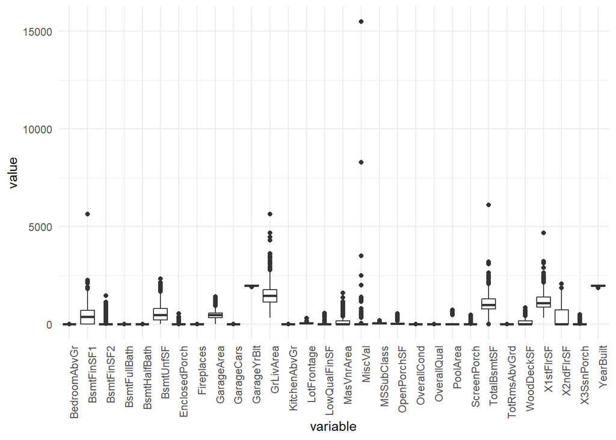

```r
out_col = setdiff(names(outlier_check)[outlier_check > 0], c("LotArea", "SalePrice"))

numeric_cols %>%
  select(all_of(out_col))%>%
  gather(key = "variable", value = "value") %>%
  ggplot(aes(x = variable, y = value)) +
  geom_boxplot() +
  theme(axis.text.x = element_text(angle = 90, hjust = 1))
```

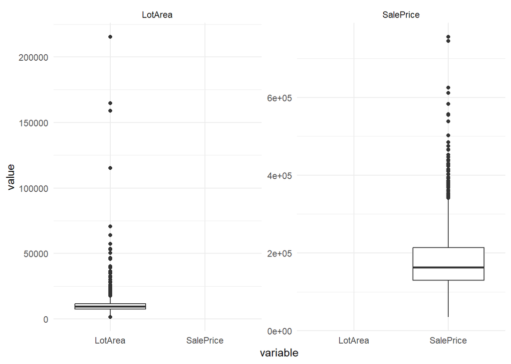

```r
train%>%
  select("LotArea", "SalePrice") %>%
  gather(key = "variable", value = "value") %>%
  ggplot(aes(x = variable, y= value)) +
  geom_boxplot() +
  facet_wrap(~variable, scales = "free_y")
```

```r
# Function to check if each factor column has only one level
check_single_level <- function(data) {
  single_level_cols <- sapply(data, function(col) {
    if (is.factor(col) && nlevels(col) == 1) {
      return(TRUE)
    } else {
      return(FALSE)
    }
  })

  # Print column names with only one level
  single_level_col_names <- names(single_level_cols[single_level_cols])
  if (length(single_level_col_names) > 0) {
    print("Columns with only one level:")
    print(single_level_col_names)
  } else {
    print("No columns with only one level found.")
  }
}

# Apply the function to your dataset
check_single_level(test)
```

```
[1] "Columns with only one level:"
[1] "Utilities"
```

```r
check_single_level(train)
```

```
[1] "No columns with only one level found."
```

```r
levels(test$Utilities)
```

```
[1] "AllPub"
```

```r
all_data <- rbind(train[,-ncol(train)], test)

combined_levels <- lapply(all_data, function(x) if(is.factor(x)) levels(x) else NULL)

for(col in names(combined_levels)) {
   if(!is.null(combined_levels[[col]])) {
     levels(train[[col]]) <- combined_levels[[col]]
     levels(test[[col]]) <- combined_levels[[col]]
   }
}

dummy = dummyVars(" ~ .", data = train[, -ncol(train)])
train_d = data.frame(predict(dummy, newdata = train))
test_d = data.frame(predict(dummy, newdata = test))
train_d = cbind(train_d,SalePrice = train$SalePrice)
```

```r
xgb_grid <- expand.grid(
  nrounds = c(50, 100),
  max_depth = c(3, 6),
  eta = c(0.1, 0.3),
  gamma = c(0, 1),
  colsample_bytree = c(0.5, 1),
  min_child_weight = c(1, 5),
  subsample = c(0.5, 1)
)

enet_grid <- expand.grid(
  alpha = seq(0, 1, 0.1),
  lambda = seq(0.01, 0.1, 0.01)
)

rf_grid <- expand.grid(
  mtry = c(2, 25, 50, 100),
  splitrule = c("variance", "extratrees"),
  min.node.size = c(1, 5, 10)
)

earth_grid <- expand.grid(
  degree = c(1, 2, 3),  # Polynomial degree
  nprune = c(10, 20, 30)  # Number of terms to prune
)

stack_control <- trainControl(
  method = "cv",
  number = 5,
  savePredictions = "all",
  classProbs = FALSE
)

tune_list <- list(
  xgb = caretModelSpec(method = "xgbTree", tuneGrid = xgb_grid),
  enet = caretModelSpec(method = "glmnet", tuneGrid = enet_grid),
#  rf = caretModelSpec(method = "ranger", tuneGrid = rf_grid),
  earth = caretModelSpec(method = "earth", tuneGrid = earth_grid)
)
set.seed(666)
all_models <- caretList(
  SalePrice ~ .,
  data = train_d,
  trControl = stack_control,
  tuneList = tune_list)
```

[output not shown]

[output cut: 265 more lines]

[output not shown]

```r
ensemble_model <- caretStack(
  all.models = all_models,
  method = "rf",
  metric = "RMSE",
  trControl = stack_control,
  tuneLength = 3
)
```

```r
print(ensemble_model)
```

```
The following models were ensembled: xgb, enet, earth

caret::train model:
Random Forest

1460 samples
   3 predictor

No pre-processing
Resampling: Cross-Validated (5 fold)
Summary of sample sizes: 1167, 1169, 1168, 1169, 1167
Resampling results across tuning parameters:

  mtry  RMSE   Rsquared  MAE
  2     30200  0.857     16099
  3     30835  0.852     16275

RMSE was used to select the optimal model using the smallest value.
The final value used for the model was mtry = 2.

Final model:

Call:
 randomForest(x = x, y = y, mtry = param$mtry)
               Type of random forest: regression
                     Number of trees: 500
No. of variables tried at each split: 2

          Mean of squared residuals: 9.73e+08
                    % Var explained: 84.6
```

```r
print(log(ensemble_model$error$RMSE))
```

```
[1] 10.3 10.3
```

```r
test_predictions = predict(ensemble_model, newdata = test_d)
```

```r
final_form <- data.frame(Id = test$Id, SalePrice = test_predictions)
colnames(final_form)[2] = "SalePrice"
final_form %>%
  write.csv(file = "ashley_miller_666-1.csv", row.names = F, quote = F)
```

Kaggle Name: ashleymiller666 Current score: 0.15910 Current position: 3139